# Homework #8: Clustering

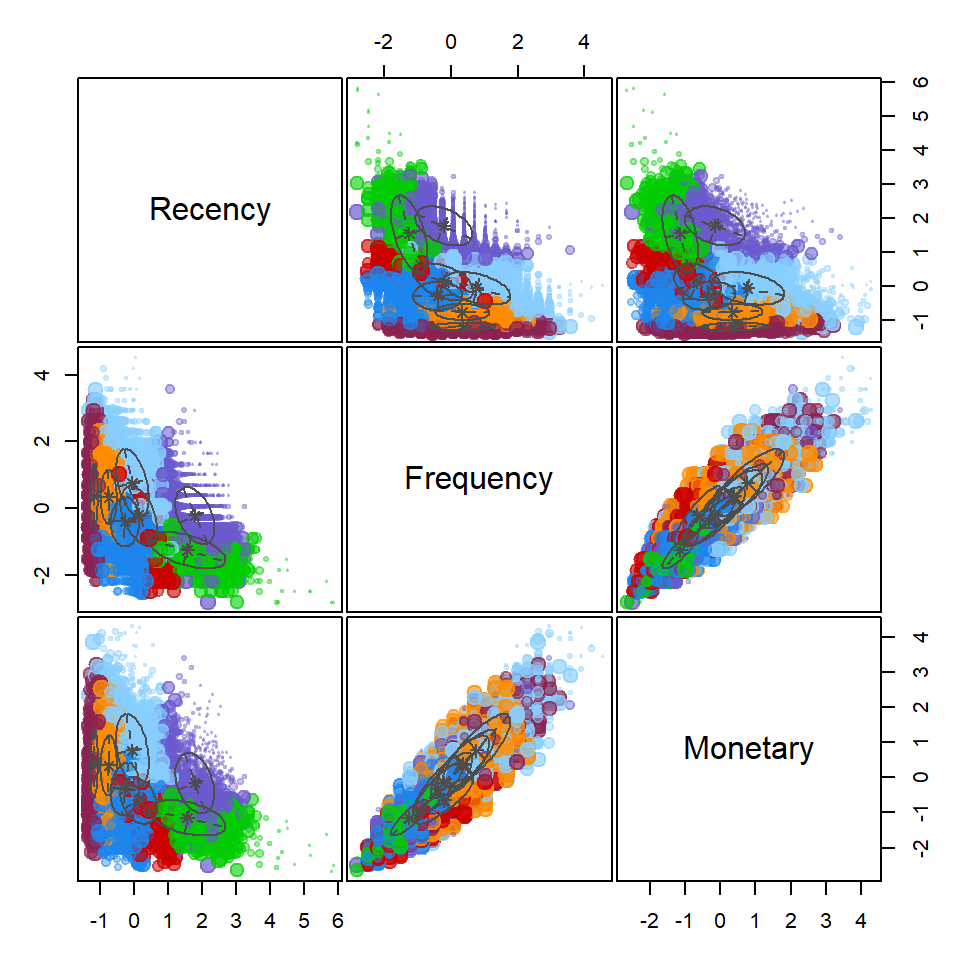

```r
plot(mix, what="uncertainty")
```

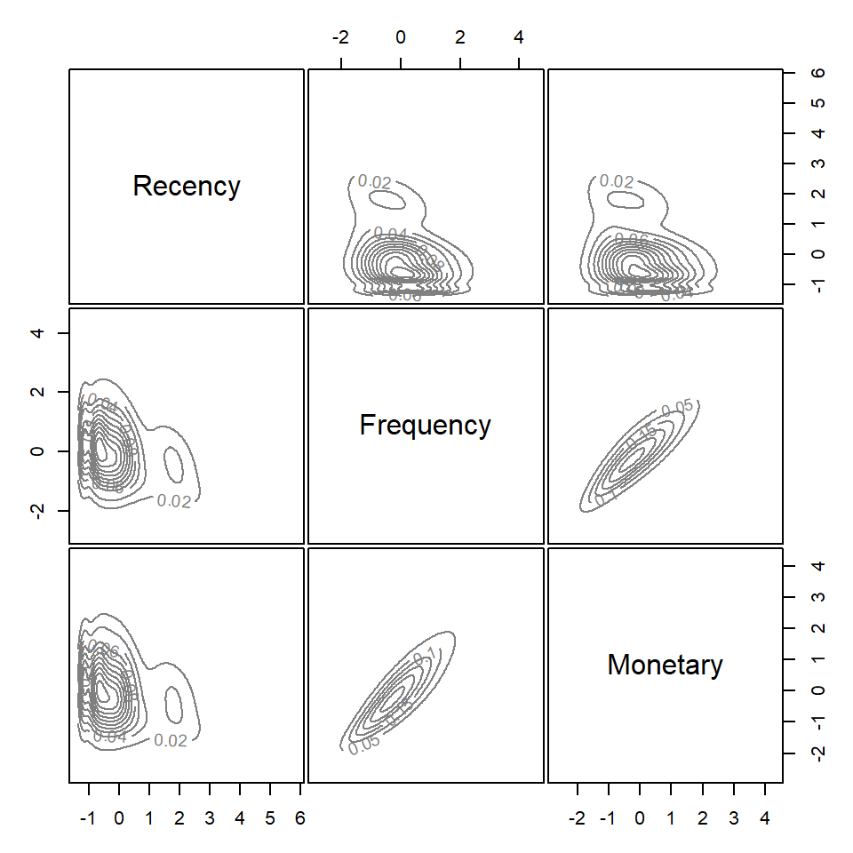

```r
plot(mix, what="density")
```

```r
#-- get parameters
summary(mix, parameters=TRUE)
```

```
#> ----------------------------------------------------
#> Gaussian finite mixture model fitted by EM algorithm
#> ----------------------------------------------------
#>
#> Mclust VVV (ellipsoidal, varying volume, shape, and orientation) model with 7
#> components:
#>
#>  log-likelihood     n df    BIC    ICL
#>          -32994 10000 69 -66624 -75557
#>
#> Clustering table:
#>    1    2    3    4    5    6    7
#> 3201  759  480 1224 1939 1490  907
#>
#> Mixing probabilities:
#>       1       2       3       4       5       6       7
#> 0.28470 0.08911 0.05708 0.12136 0.18827 0.18527 0.07422
#>
#> Means:
#>              [,1]    [,2]   [,3]    [,4]    [,5]     [,6]    [,7]
#> Recency   -0.2732  0.1331  1.553  1.7827 -0.7514 -0.05418 -1.1802
#> Frequency -0.4000 -0.2131 -1.255 -0.2221  0.3356  0.76473  0.3586
#> Monetary  -0.3279 -0.6515 -1.149 -0.1540  0.3411  0.76956  0.3890
#>
#> Variances:
#> [,,1]
#>            Recency Frequency Monetary
#> Recency   0.174524  0.006262  0.04564
#> Frequency 0.006262  0.548426  0.47372
#> Monetary  0.045637  0.473724  0.56103
#> [,,2]
#>           Recency Frequency Monetary
#> Recency    0.2914   -0.2112  -0.1044
#> Frequency -0.2112    0.7706   0.5067
#> Monetary  -0.1044    0.5067   0.4452
#> [,,3]
#>           Recency Frequency Monetary
#> Recency    1.2782   -0.3231  -0.2460
#> Frequency -0.3231    0.2991   0.2347
#> Monetary  -0.2460    0.2347   0.2535
#> [,,4]
#>           Recency Frequency Monetary
#> Recency    0.3312   -0.2101  -0.1655
#> Frequency -0.2101    0.7309   0.5873
#> Monetary  -0.1655    0.5873   0.7323
#> [,,5]
#>             Recency Frequency Monetary
#> Recency    0.057060 -0.008395  0.01279
#> Frequency -0.008395  0.661235  0.51687
#> Monetary   0.012791  0.516869  0.72876
#> [,,6]
#>           Recency Frequency Monetary
#> Recency    0.2317   -0.2141  -0.1636
#> Frequency -0.2141    1.0275   0.8542
#> Monetary  -0.1636    0.8542   1.0866
#> [,,7]
#>            Recency Frequency Monetary
#> Recency   0.012663  0.008242  0.01137
#> Frequency 0.008242  0.941335  0.78274
#> Monetary  0.011368  0.782737  0.93192
```

```r
mix[["BIC"]]
```

```
#> Bayesian Information Criterion (BIC):
#>      EII    VII    EEI    VEI    EVI    VVI    EEE    VEE    EVE    VVE    EEV
#> 1 -85170 -85170 -85189 -85189 -85189 -85189 -70975 -70975 -70975 -70975 -70975
#> 2 -79894 -79560 -78355 -78339 -76949 -76919 -70678 -67725 -67541 -67528 -67594
#> 3 -75392 -74932 -75350 -74908 -75370 -73552 -67461 -67424 -67303 -67254 -67275
#> 4 -73137 -72144 -72942 -72087 -72425 -72088 -67496 -67286 -67236 -67073 -67241
#> 5 -72410 -71075 -71685 -70752 -70935 -69797 -67379 -67214 -66814 -67082 -67041
#> 6 -72153 -70675 -70893 -70108 -70137 -69049 -67416 -67175 -66723 -67109 -66911
#> 7 -69959 -69553 -70529 -68887 -69142 -68781 -67421 -67107 -66731 -67169 -66888
#> 8 -69356 -69101 -69026 -68551 -68580 -68421 -67456 -67069 -66756 -67200 -66783
#> 9 -69076 -68891 -68930 -68416 -68284 -68287 -67493 -67071 -66713 -67094 -66834
#>      VEV    EVV    VVV
#> 1 -70975 -70975 -70975
#> 2 -67604 -67456 -67426
#> 3 -67358 -67183 -67106
#> 4 -67112 -66877 -67061
#> 5 -67073 -66790 -66848
#> 6 -66963 -66771 -66715
#> 7 -66927 -66782 -66624
#> 8 -66979 -66776 -66668
#> 9 -66978 -66786 -66847
#>
#> Top 3 models based on the BIC criterion:
#>  VVV,7  VVV,8  EVE,9
#> -66624 -66668 -66713
```

```r
#c4
#membership
member3 = mix$classification
member3[1] == member3[100]
```

```
#> [1] FALSE
```

```r
#customers 1 and 100 are not in same cluster.
```

## d. Discuss how you would cluster the customers if you had to do this for your job. Do you think one model would do better than the others?

If this task is part of my job, I think i will give a shot to all these three models to cluster customers. Based on the demand of companies, if they have labeled test data, we can try performance of each model and see which one perform the best. If there is no labeled test data, I will see aim of our clustering, like grouping customers who have higher chance to re-visit and consume again. We can see whether the cluster result fulfill this goal. In sum, based on the demand to pick our clustering model.

We cannot say one model is certainly better than the others. With a different aspect of testing the performance, any model can have the best performance. At the same time, those models have variance and even with a different scaling, the result will be totally different. So, we cannot say which one is the best.

# Problem 2: Poisson Mixture Model (OPTIONAL: NOT GRADED)

The pmf of a Poisson random variable is:
$$\begin{align*}
f_k(x; \lambda_k) = \frac{\lambda_k^x e^{-\lambda_k}}{x!}
\end{align*}$$

A two-component Poisson mixture model can be written:
$$\begin{align*}
f(x; \theta) = \pi \frac{\lambda_1^x e^{-\lambda_1}}{x!} + (1-\pi) \frac{\lambda_2^x e^{-\lambda_2}}{x!}
\end{align*}$$

## e. Fit a two-component Poisson mixture model, report the estimated parameter values, and show a plot of the estimated mixture pmf for the following data:

```r
#-- Run this code to generate the data
set.seed(123)             # set seed for reproducibility
n = 200                   # sample size
z = sample(1:2, size=n, replace=TRUE, prob=c(.25, .75)) # sample the latent class
theta = c(8, 16)          # true parameters
y = ifelse(z==1, rpois(n, lambda=theta[1]), rpois(n, lambda=theta[2]))
```

Note: The function `poisregmixEM()` in the R package `mixtools` is designed to estimate a mixture of *Poisson regression* models. We can still use this function for our problem of density estimation if it is recast as an intercept-only regression. To do so, set the $x$ argument (predictors) to `x = rep(1, length(y))` and `addintercept = FALSE`.

Look carefully at the output from this model. The `beta` values (regression coefficients) are on the log scale.

## f. **2 pts Extra Credit**: Write a function that estimates this two-component Poisson mixture model using the EM approach. Show that it gives the same result as part *e*.

- Note: you are not permitted to copy code. Write everything from scratch and use comments to indicate how the code works (e.g., the E-step, M-step, initialization strategy, and convergence should be clear).
- Cite any resources you consulted to help with the coding.